# Lecture 5

# Strength of seasonality and trend

```r
library(fpp3)
```

## Feature extraction and statistics

| Region | State | Purpose | trend_strength | seasonal_strength_year | seasonal_peak_year | seasonal_trough_year | spikiness | linearity | curvature | stl_e_acf1 | stl_e_acf10 |
| --- | --- | --- | --- | --- | --- | --- | --- | --- | --- | --- | --- |
| Adelaide | South Australia | Business | 0.4514189 | 0.37992568 | 3 | 1 | 1.615980e+02 | -5.51264159 | 71.3983780 | -0.5464023 | 0.5405303 |
| Adelaide | South Australia | Holiday | 0.5411193 | 0.60128337 | 1 | 3 | 9.951272e+00 | 48.88549816 | 78.1536328 | -0.5114545 | 0.5039100 |
| Adelaide | South Australia | Other | 0.7427272 | 0.18895204 | 2 | 1 | 2.281497e+00 | 94.98538149 | 43.4373778 | -0.3555120 | 0.3788245 |
| Adelaide | South Australia | Visiting | 0.4332942 | 0.44618013 | 1 | 3 | 6.006530e+01 | 34.87782914 | 71.1316259 | -0.5018451 | 0.9190606 |
| Adelaide Hills | South Australia | Business | 0.4534935 | 0.13990506 | 3 | 1 | 1.177351e-01 | 0.94367013 | -3.2992083 | -0.5993566 | 0.4661008 |
| Adelaide Hills | South Australia | Holiday | 0.5115746 | 0.24371910 | 2 | 1 | 1.920763e-01 | 10.39778069 | 23.8227565 | -0.4772485 | 0.3143618 |
| Adelaide Hills | South Australia | Other | 0.5841891 | 0.37426658 | 2 | 2 | 5.016938e-04 | 4.29303338 | 3.2080199 | -0.2962595 | 0.2684300 |
| Adelaide Hills | South Australia | Visiting | 0.4809335 | 0.22793823 | 0 | 3 | 7.564863e+00 | 34.26291895 | -0.5871027 | -0.4680728 | 0.4093888 |
| Alice Springs | Northern Territory | Business | 0.5255087 | 0.22430134 | 0 | 1 | 1.786159e-01 | 23.81264737 | 19.5994525 | -0.4917540 | 0.5358313 |
| Alice Springs | Northern Territory | Holiday | 0.3770119 | 0.82686447 | 3 | 1 | 8.131590e-01 | -19.62918767 | 10.3259569 | -0.5148905 | 0.6461633 |

[output cut: 294 more lines]

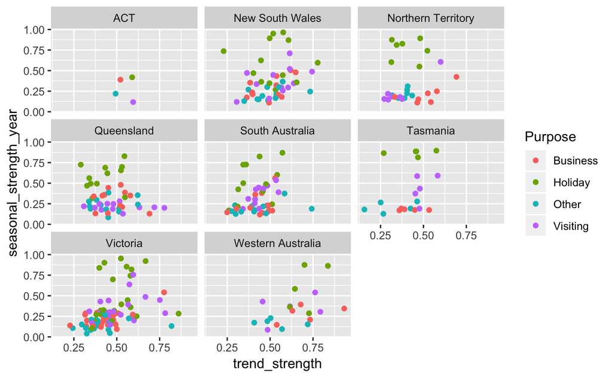

Holidays more seasonal than other types (green dots high on y axis). Western Australia has the strongest trends.

Find the most seasonal time series:

```r
most_seasonal <- tourism %>%
  features(Trips, feat_stl) %>%
  filter(seasonal_strength_year == max(seasonal_strength_year))
```

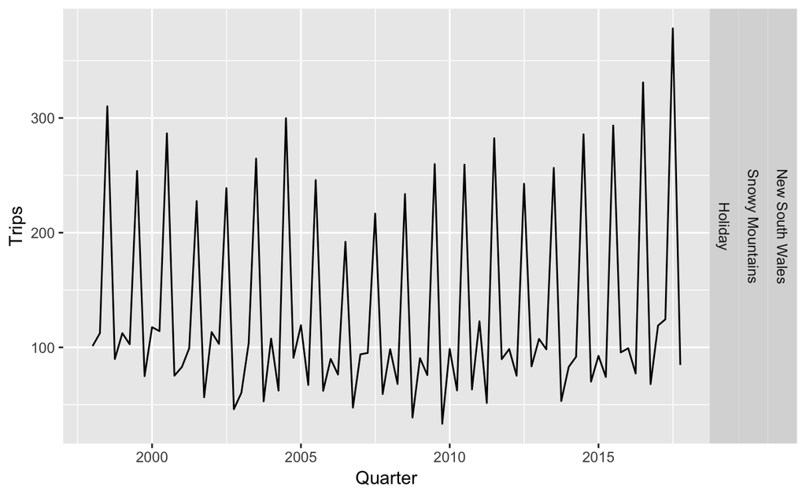

Same for most trended time series:

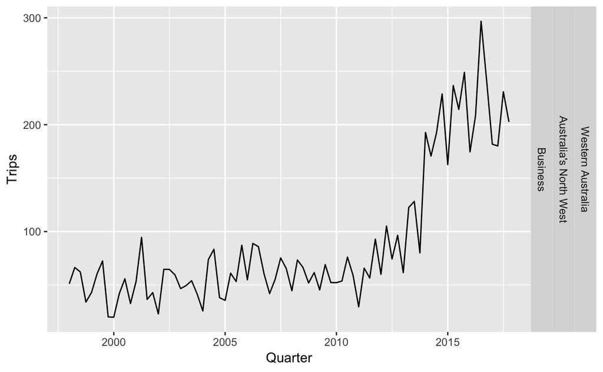

# Lab session 9

Use `GGally::ggpairs()` to look at the relationship between STL features. You might need to change `seasonal_peak_year` and `seasonal_trough_year` to factors.

```r
tourism %>%
  features(Trips, feat_stl) %>%
  select(-Region, -State, -Purpose) %>%
  mutate(
    seasonal_peak_year = factor(seasonal_peak_year),
    seasonal_trough_year = factor(seasonal_trough_year)
  ) %>%
  GGally::ggpairs()
```

[output not shown]

This shows us where strange outlying values are. For isntance, very spikey series.

| Region | State | Purpose | trend_strength | seasonal_strength_year | seasonal_peak_year | seasonal_trough_year | spikiness | linearity | curvature | stl_e_acf1 | stl_e_acf10 |
| --- | --- | --- | --- | --- | --- | --- | --- | --- | --- | --- | --- |
| Brisbane | Queensland | Business | 0.5476879 | 0.3862033 | 3 | 1 | 2392.463 | 248.30683 | 171.1094 | -0.4541389 | 0.5427855 |
| Sydney | New South Wales | Business | 0.6490397 | 0.4789352 | 3 | 1 | 6067.203 | 41.58560 | 502.2821 | -0.5393994 | 0.3938498 |
| Sydney | New South Wales | Holiday | 0.5735503 | 0.4448151 | 1 | 0 | 2787.055 | 98.46414 | 231.0930 | -0.4331939 | 0.4318532 |

Which is the peak quarter for travel in each state?

| State | trend_strength | seasonal_strength_year | seasonal_peak_year | seasonal_trough_year | spikiness | linearity | curvature | stl_e_acf1 | stl_e_acf10 |
| --- | --- | --- | --- | --- | --- | --- | --- | --- | --- |
| ACT | 0.7179827 | 0.1527191 | 2 | 1 | 653.9711 | 298.6750 | 329.2724 | -0.3918916 | 0.3221585 |
| New South Wales | 0.9019857 | 0.7412400 | 1 | 3 | 221659.6065 | 992.7259 | 3940.4016 | -0.4338563 | 0.3299442 |
| Northern Territory | 0.7091928 | 0.9147768 | 3 | 1 | 1049.0774 | 269.1608 | 232.2179 | -0.4760243 | 0.4035372 |
| Queensland | 0.8190940 | 0.5940407 | 3 | 1 | 1013345.8042 | 2953.4181 | 1365.6549 | -0.4224825 | 0.4246594 |
| South Australia | 0.7407040 | 0.7629640 | 1 | 3 | 5174.9913 | 250.5482 | 645.3865 | -0.4322619 | 0.3433964 |
| Tasmania | 0.6024952 | 0.9012774 | 1 | 3 | 4158.7859 | 260.9344 | 242.0357 | -0.3484316 | 0.7660980 |
| Victoria | 0.9324993 | 0.9252853 | 1 | 3 | 97738.9364 | 2687.0536 | 3171.7273 | -0.4183582 | 0.4378776 |
| Western Australia | 0.9407443 | 0.3498689 | 1 | 3 | 136621.2683 | 1940.3440 | 1920.0070 | -0.3541856 | 0.2940058 |

Features can be used for anomaloy detection across many time series.

## PCA on all feature sets

```r
# compute all features
tourism_features <- tourism %>%
  features(Trips, feature_set(pkgs = "feasts"))
```

```
304 errors (1 unique) encountered for feature 16
[304] The `ForeCA` package must be installed to use this functionality. It can be installed with install.packages("ForeCA")
```

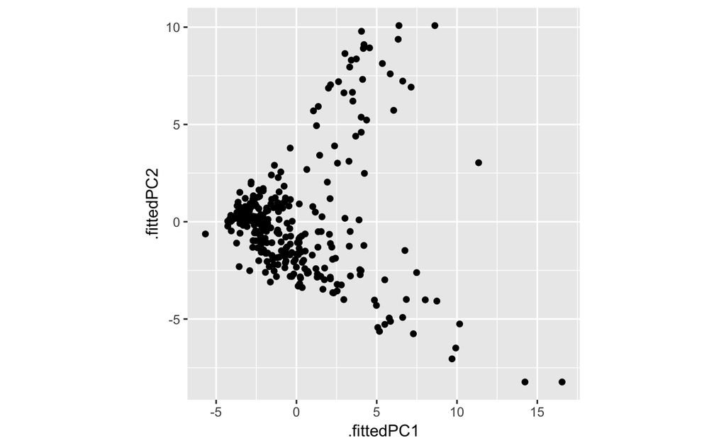

What’s going on here?

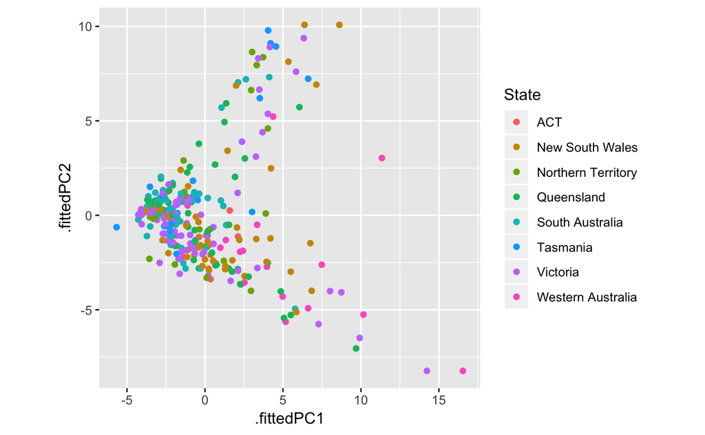

Coloring by “State” doesn’t help us. What about by “Purpose”?

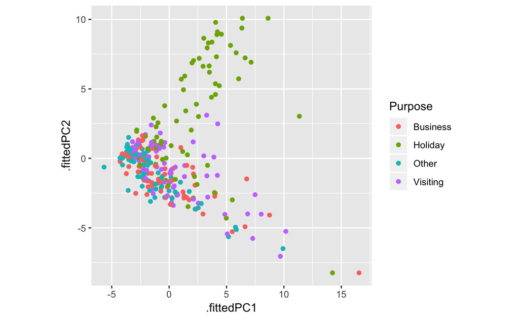

Filter for interesting outliers.

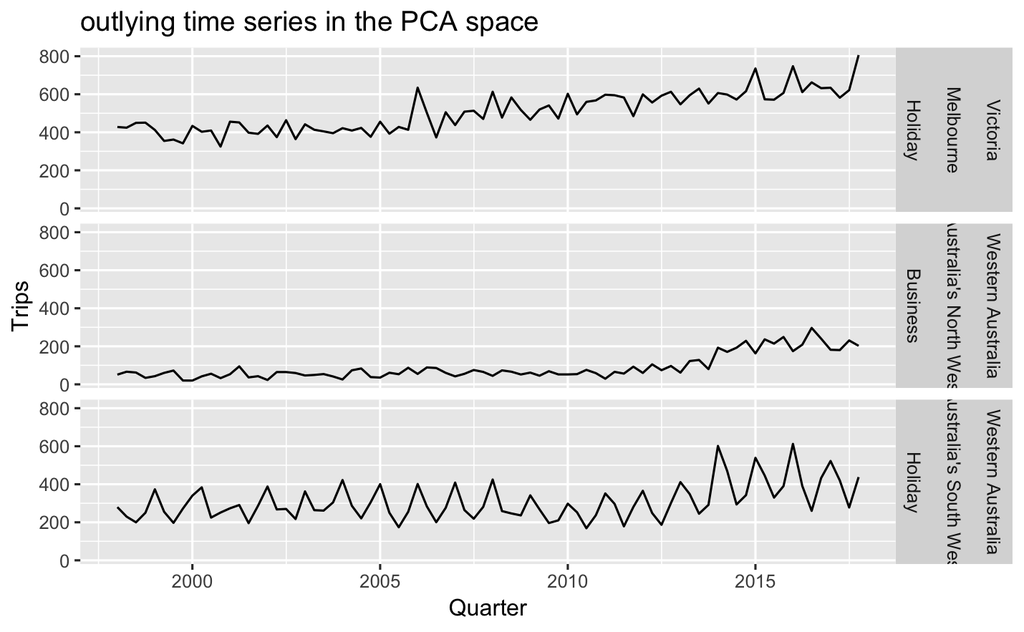

# Lab session 10

Use a features based approach to look for outlying series in PBS (Monthly Medicare Australia prescription data).

```r
pf <- PBS %>% features(Cost, feature_set(pkgs = "feasts"))
```

[output not shown]

This won’t work because two series have all zeros, and you can’t compute models for data sets with all constants!

```r
# remove series with all zeros as features
PBS_no_zeros <- PBS %>%
  group_by_key() %>%
  filter(!all(Cost == 0)) %>%
  ungroup()

# recompute PCs
pbs_features <- PBS_no_zeros %>% features(Cost, feature_set(pkgs = "feasts"))

# look for bad features caused by messy data that we didn't clean properly
summary(pbs_features)
```

[output not shown]

Visualize the outlying series.

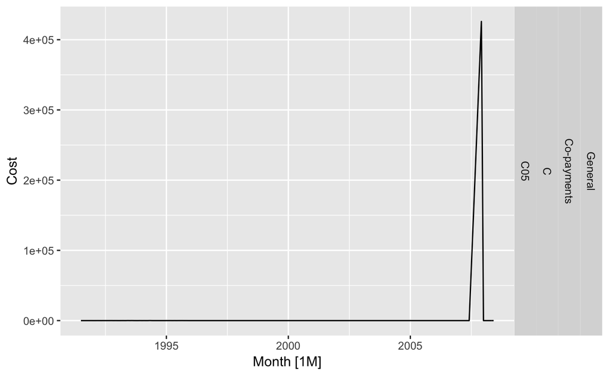